# Pràctica 2

# 5. Representació dels resultats a partir de taules i gràfiques.

```r
library(plyr)
#estadística descriptiva del preu de lloguer per parròquia
ddply(parroquies_centrals, .(parroquia), summarize,
      minim=min(preu,na.rm = TRUE),
      mitjana = round(mean(preu,na.rm = TRUE), 2),
      maxim=max(preu,na.rm = TRUE),
      mediana = round(median(preu,na.rm = TRUE), 2),
      desviacio = round(sd(preu,na.rm = TRUE), 2),
      preu_m2=round(mean(pm2,na.rm=TRUE),2),
      habitacions=round(mean(numHabitacions, na.rm=TRUE),0),
      metres_quadrats=round(mean(m2, na.rm=TRUE),1),
      n=length(preu))
```

```
##          parroquia minim mitjana maxim mediana desviacio preu_m2
## 1 andorra la vella   800 1461.68  5900    1200    967.06   11.43
## 2         escaldes   750 1287.67  4000    1150    587.86   11.99
##   habitacions metres_quadrats   n
## 1           3           134.9 112
## 2           3           108.0  78
```

```r
ddply(parroquies_centrals, .(numHabitacions, parroquia), summarize,
      minim=min(preu,na.rm = TRUE),
      mitjana = round(mean(preu,na.rm = TRUE), 2),
      maxim=max(preu,na.rm = TRUE),
      mediana = round(median(preu,na.rm = TRUE), 2),
      desviacio = round(sd(preu,na.rm = TRUE), 2),
      preu_m2=round(mean(pm2,na.rm=TRUE),2),
      habitacions=round(mean(numHabitacions, na.rm=TRUE),0),
      metres_quadrats=round(mean(m2, na.rm=TRUE),1),
      n=length(preu))
```

```
##   numHabitacions        parroquia minim mitjana maxim mediana desviacio
## 1              1 andorra la vella   800  909.09  1100   900.0     72.69
## 2              1         escaldes   750  750.00   750   750.0        NA
## 3              2 andorra la vella   850 1155.06  3200  1058.5    400.36
## 4              2         escaldes   800  988.58  1300   900.0    154.08
## 5              3 andorra la vella   964 1564.40  5900  1250.0   1110.90
## 6              3         escaldes   950 1432.50  4000  1150.0    688.35
## 7              4 andorra la vella  1200 2297.92  4500  1660.0   1140.83
## 8              4         escaldes  1200 1618.00  2000  1590.0    376.99
##   preu_m2 habitacions metres_quadrats  n
## 1   12.65           1            79.4 11
## 2   18.75           1            40.0  1
## 3   11.94           2            95.9 32
## 4   11.47           2            90.2 26
## 5   11.09           3           147.1 57
## 6   12.06           3           117.4 46
## 7   10.53           4           232.4 12
## 8   12.72           4           127.6  5
```

```r
# Library
#################################################
library(leaflet)

# Com les dades són de territori, aprofitarem per afegir les coordenades i fer un mapa
quakes<-ddply(parroquies_centrals, .(parroquia), summarize,
              minim=min(preu,na.rm = TRUE),
              mitjana = round(mean(preu,na.rm = TRUE), 2),
              maxim=max(preu,na.rm = TRUE),
              mediana = round(median(preu,na.rm = TRUE), 2),
              desviacio = round(sd(preu,na.rm = TRUE), 2),
              preu_m2=round(mean(pm2,na.rm=TRUE),2),
              habitacions=round(mean(numHabitacions, na.rm=TRUE),0),
              metres_quadrats=round(mean(m2, na.rm=TRUE),1),
              n=length(preu))
quakes$lat[quakes$parroquia =="andorra la vella"] = 42.5077896
quakes$long[quakes$parroquia =="andorra la vella"] = 1.52109
quakes$lat[quakes$parroquia =="escaldes"] = 42.5072899
quakes$long[quakes$parroquia =="escaldes"] = 1.53414

quakes$preu<-round(quakes$preu,1)
quakes$metres_quadrats<-round(quakes$metres_quadrats,0)
quakes$habitacions<-round(quakes$habitacions,1)

# Create a color palette with handmade bins.
mybins=seq(11, 12.4, by=0.2)
mypalette = colorBin( palette="YlOrBr", domain=quakes$preu_m2, na.color="transparent", bins=mybins)

# Prepar the text for the tooltip:
mytext=paste("<B> Parròquia: ", quakes$parroquia, " </B> <br/>", "Preu mitjà de lloguer: ", quakes$preu,
             "<br/>", "Nombre d'habitacions: ", quakes$habitacions, "<br/>", "Preu mitjà per m2: ", quakes$preu_m2,
             "<br/>", "Metres quadrats: ", quakes$metres_quadrats,"<br/>", "Nombre de vivendes disponibles: ", quakes$n, "<br/>", sep="") %>%
  lapply(htmltools::HTML)

#mapa a R
leaflet(quakes) %>%
  setView( lat=42.5072456 , lng=1.531254 , zoom=14) %>%
  addProviderTiles("Esri.WorldImagery") %>%
  addTiles() %>%
  addCircleMarkers(~long, ~lat,
                   fillColor = ~mypalette(preu_m2), fillOpacity = 0.7, color="white", radius=15, stroke=FALSE,
                   label = mytext,
                   labelOptions = labelOptions( style = list("font-weight" = "normal", padding = "3px 8px"), textsize = "13px", direction = "auto")
  ) %>%
  addLegend( pal=mypalette, values=~preu, opacity=0.9, title = "Preu mitjà per metre quadrat", position = "bottomright" )
```

[interactive chart not shown]

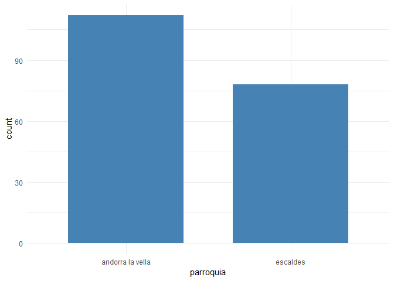

```r
#################################################
library(ggplot2)
ggplot(parroquies_centrals, aes(x=parroquia))+
  geom_bar(stat="count", width=0.7, fill="steelblue")+
  theme_minimal()
```

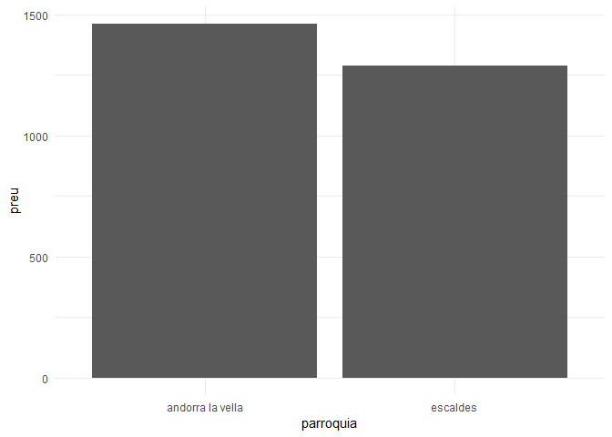

```r
ggplot(parroquies_centrals, aes(x=parroquia, y=preu))+
  geom_bar(fun.y="mean", stat = "summary")+
  theme_minimal()
```

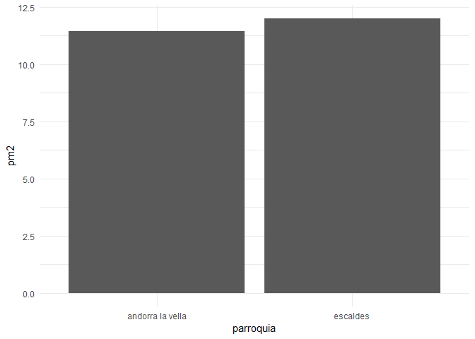

```r
ggplot(parroquies_centrals, aes(x=parroquia, y=pm2))+
  geom_bar(fun.y="mean", stat = "summary")+
  theme_minimal()
```

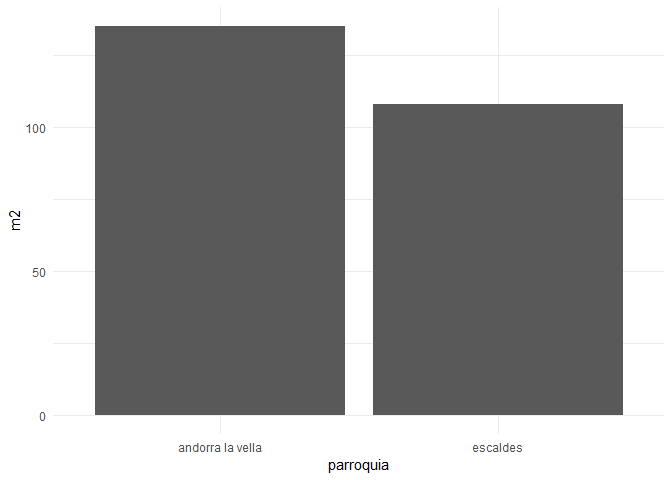

```r
ggplot(parroquies_centrals, aes(x=parroquia, y=m2))+
  geom_bar(fun.y="mean", stat = "summary")+
  theme_minimal()
```

# 6. Resolució del problema. A partir dels resultats obtinguts, quines són les conclusions? Els resultats permeten respondre al problema?

Els resultats obtinguts són que la oferta en els portals d’internet d’habitatge presenten una mitjana de preus de 1461,68€ en el cas d’Andorra la vella i una mitjana de 1287,67€ en el cas d’escaldes.

Aquests valors són significativament diferents als que es publica de mitjana segons l’Enquesta de Pressupostos Familiars, que es situa al voltan de 9 euros el m2. Per tant, els habitatges ofertats són més cars que els que hi ha actualment ja llogats.

Entre parròquies, s’ha de destacar que les parròquies centrals no presenten diferències significatives en el seu preu per m2 segons el test de mann-whitney-wilcoxon.

# 7. Codi: Cal adjuntar el codi, preferiblement en R, amb el que s’ha realitzat la neteja, anàlisi i representació de les dades. Si ho preferiu, també podeu treballar en Python.

```r
write.csv2(anuncis_habitatges_andorra2, "C:/Users/jordi/OneDrive/Desktop/dades_posteriors.csv")

data.frame("Autor"=c("Jordi Fuster i Joan Ribera", "Jordi Fuster i Joan Ribera", "Jordi Fuster i Joan Ribera"), "Contribucions"=c("Investigació prèvia", "Redacció de respostes", "Desenvolupament del codi"))
```

```
##                        Autor            Contribucions
## 1 Jordi Fuster i Joan Ribera      Investigació prèvia
## 2 Jordi Fuster i Joan Ribera    Redacció de respostes
## 3 Jordi Fuster i Joan Ribera Desenvolupament del codi
```